# Comic Book Journal

```r
library(stringi)
```

## Okay What Do I Do?

The commic book data provides a few interesting ideas.

The original piece this data was used for is about the evolution of representation of gender and sexuality over the years in Marvel and DC comics.

I’ll try not to repeat this idea, but in doing so I run into my first problem:

### Problem 1: The Variables are a Bit Dull

If I’m going to go in a different direction, the variables aren’t the best. They give me a nice starting point, but I’m going to have to do a little more work if I want to do some original analysis.

Stuff like “ALIGN” (whether the character is good or evil), “APPEARANCES”, “YEAR” (year of first appearance), “SEX”, and “name” could prove to be valuable, but the biggest gift from this dataset is the “slug” variable, which should give me an easy way to use rvest to iterate through characters’ URLs to look for more more interesting variables.

```r
dc_data %>%
  colnames()
```

```
 [1] "page_id"          "name"             "urlslug"          "ID"               "ALIGN"            "EYE"
 [7] "HAIR"             "SEX"              "GSM"              "ALIVE"            "APPEARANCES"      "FIRST APPEARANCE"
[13] "YEAR"
```

Let’s create a new dataframe with a “full_url” column

## My First Idea: What Do Superheroes Do When They’re Not Being Superheroes?

One of the variables that caught my eye early (after I spent a few minutes musing on whether height and weight was enough to assemble a superhero basketball team for each universe) was the “occupation” field listed on many of the superhero wikia pages.

I found this a really interesting for a few reasons:

1. It’s an easy way of ascribing class to comic book characters. Class isn’t something that’s mentioned all that often in comic books (at least as far as I know). Part of the reason superheroes inspire so many of us is because superpowers remove resources as a constraint on potential. Superheroes can often punch and kick their way out of problems that would be far more complicated for normal people. But it makes me wonder, is there a clear distinction of classes among superheroes? Are there poor superheroes? Are more villains poor?
2. It gives a character additional depth. Spider-Man is a wonderful example of this. He is a more effective character because he is a normal person who we often see going to school and working jobs. We see the personal sacrifices Peter Parker makes in terms of his time and responsibilities to fight crime, so each time he bolts out of a room to suit up, it feels impactful because we can all relate to that kind of sacrifice.
3. How many jobs can you work and still fight crime: One of the first things I noticed was that many characters had multiple jobs. It made me wonder about the typical time commitment for superhero activities.

### So tons of interesting questions to answer

and I’m super I’ll come up with more but the next step here is to figure out all these characters’ jobs which led me to problem 2

### Problem 2: The job getting function

The following function produces a list of jobs scraped from dc wikia for the first 200 characters on the dc list.

It’s not 100% perfect but I was pleasantly surprised by the results given the fairly generic html node

First I’ll talk about the problems (most of which seem pretty solvable):

First, the obvious: there are about ~30 characters missing an occupation field. For some it is because the node is a bit different, for some the url generated from the “urlslug” field returned a 404. I’ll examine those more closely this week, but the relatively small number makes me a little less averse to doing those by hand

Second, some of the results seem to be from a different field. Not sure how many of these (although it doesn’t seem to be many) look to be marital statuses. Not 100% surprised given marital status is generally close to occupation on the page but still a bit disappointed nonetheless

Third, there’s still some work to be done standardizing the field. Some jobs are separated by “.”, while some are separated by “,”.

Anyways, I think I’m off to a good start here and the work this week will mostly revolve around refining the scraping function and then hopefully jumping into some analysis

# Kind of a bummer: On the scraper

I was hopeful at first when I saw that marvel and DC wikia both had standarized website layouts with a lot of scrapable nodes.

However, I quickly ran into some problems that dragged this thing down just a little. I’ll attempt to explain each and what I did to mitigate.

## Where is the job?

As you can probably tell from the scrapers below, the “occupation” section of the Marvel Wikia and the corresponding section on DC wikia generally appeared on differently named nodes. This was among the first red flags in the data and suggested to me immediately that I would not be able to get job data for everyone. From there it didn’t take me too long to run into problem #2

## Is Job location the same for every character?

Sadly no. While the location for the occupation node is *generally* in the same place, that is not universally the case. Trying different nodes also had diminishing returns as it required more and more work for fewer and fewer correct matches. It also became clear after some testing that not every character even had an occupation field on either site

## How many characters even have jobs?

This is the unknowable question whose spector haunts this project for me. Some characters (a character with only a few appearances especially) will often not have jobs. Maybe their job wasn’t relevant for the story. Maybe we didn’t follow them long enough in the story to see their work. But their occupation node is totally empty.

The problem for me is there’s no way of knowing whether I am missing the occupation node for a character because they do not have an occupation or because I got the node wrong. Functionally there is no difference, but I wish I had a way of working around this.

## Where I landed

Ultimately I decided to analyze smaller subset of the data for this project. It contains job data for about 2,500 characters in the data. This is a little over 10% of the total characters in the data but a much larger percentage of total appearances, allowing me to justify it to myself as a representative sample. In any case it’s too late to turn back now so I will do my best.

```r
# Scraper is below but I'm going to save you seome time and include the rds

readRDS(gdxg, "data/gdxg.rds")
readRDS(gdxg_marvel, "data/gdxg_marvel.rds")
page<- (dc_test$full_url)



gdxg <- lapply(page, function(i) {

 tryCatch(
  i %>%
    read_html %>%
    html_nodes(".pi-item-spacing+ .pi-border-color .pi-border-color:nth-child(6) .pi-font") %>%
    html_text(),
  error = function(e){NA}
 )
})


gdxg_marvel <- future_map(page_marvel, function(i) {

  tryCatch(
    i %>%
      read_html %>%
      html_nodes(".pi-collapse:nth-child(10) .pi-border-color:nth-child(4) .pi-font") %>%
      html_text(),
    error = function(e){NA}
  )
})

gdxg_marvel[lengths(gdxg) == 0] <- NA_character_
gdxg[lengths(gdxg) == 0] <- NA_character_

hero_jobs_test <- unlist(gdxg)
test_list_marvel <- lapply(gdxg_marvel, function(x) if(identical(x, character(0))) NA_character_ else x)

marvel_job_test <- test_list_marvel %>%
  unlist()

dc_data$job <- hero_jobs_test
marvel_5000 <- marvel_data[1:5000,]

marvel_5000$job <- marvel_job_test

marvel_5000$universe <- "Marvel"
dc_data$universe <- "DC"

hero_jobs_test
```

```r
jobs_test_dc <- dc_data %>%
  mutate(job = str_to_upper(job)) %>%
  mutate(job = case_when(job == "MARRIED" ~ NA_character_,
                         job == "SINGLE" ~ NA_character_,
                         job == "WIDOWED" ~ NA_character_,
                         job == "DIVORCED" ~ NA_character_,
                         job == "MOBILE" ~ NA_character_,
                         TRUE ~ job),
         married = case_when(job == "MARRIED" ~ "MARRIED",
                         job == "SINGLE" ~ "SINGLE",
                         job == "WIDOWED" ~ "WIDOWED",
                         job == "DIVORCED" ~ "DIVORCED",
                         TRUE ~ NA_character_))

jobs_test_marvel <- marvel_5000 %>%
  mutate(job = str_to_upper(job)) %>%
  mutate(job = case_when(job == "MARRIED" ~ NA_character_,
                         job == "SINGLE" ~ NA_character_,
                         job == "WIDOWED" ~ NA_character_,
                         job == "DIVORCED" ~ NA_character_,
                         job == "MOBILE" ~ NA_character_,
                         TRUE ~ job),
         married = case_when(job == "MARRIED" ~ "MARRIED",
                         job == "SINGLE" ~ "SINGLE",
                         job == "WIDOWED" ~ "WIDOWED",
                         job == "DIVORCED" ~ "DIVORCED",
                         TRUE ~ NA_character_))
```

# Good vs Bad

First interesting thing to me is there are way more bad characters than good characters in the data. The Marvel universe is especially lopsided

I think that’s probably down to villains being more dime-a-dozen than heroes. Bad characters are necessary because conflict moves the story forward.

It might also bore readers if their heroes were encountering the same opposition in every issue.

Simply put, there’s a reason why the comic is called “Spider-Man” and not “Green Goblin”.

| ALIGN | n | universe |
| --- | --- | --- |
| Bad Characters | 6720 | Marvel |
| Good Characters | 4636 | Marvel |
| Neutral Characters | 2208 | Marvel |
| Bad Characters | 2895 | DC |
| Good Characters | 2832 | DC |
| Neutral Characters | 565 | DC |

#When were characters created?

One thing I’ve been super interested in are the most prolific eras of character creation. It seems like we live with an annoying amount of comic book content in this day and age, but is this truly the golden age of comic book characters?

```r
comic_data<-full_join(marvel_data, dc_data)
```

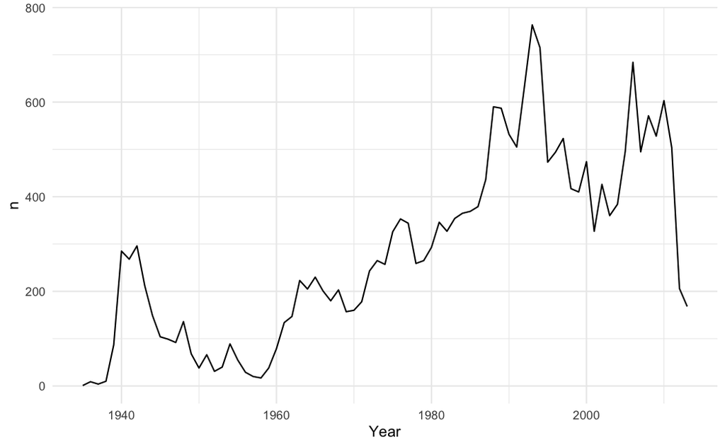

## What were the most important years in comic book history?

It’s one thing to examine raw numbers of comic book characters being created at a given time, but there are arguably too many variables to draw many meaningful conclusions. For example, comic book characters are in a golden age and we are currently creating fewer new characters than at any point in about 50 years. Conversely, comic book creators may be incentivized to throw a lot of ideas at the wall during times when business is bad, like the early 90s.

I’ll attempt to take a more sophisticated approach to calculating most impactful years in comic book history: appearances per character. This will hopefully do a much better job at measuring the efficiency with which artists were albe to create classic characcters at a given time

## Results

Muuuuuch different story here. And a very interesting story.

Likewise, the 1960s, another notable era of national anxiety was another golden era in efficiency.

By contrast, the 90s was full of duds despite being one of the most prolific eras of character creation in the data.

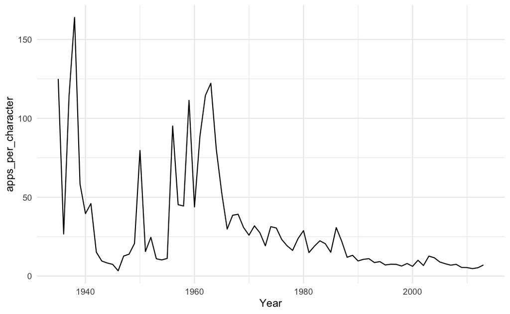

| Year | n | apps | apps_per_character |
| --- | --- | --- | --- |
| 1993 | 763 | 6540 | 8.571429 |
| 1994 | 715 | 6551 | 9.162238 |
| 2006 | 684 | 5348 | 7.818713 |
| 1992 | 633 | 6967 | 11.006319 |
| 2010 | 603 | 3241 | 5.374793 |
| 1988 | 590 | 7036 | 11.925424 |
| 1989 | 587 | 7724 | 13.158433 |
| 2008 | 571 | 4242 | 7.429072 |
| 1990 | 532 | 5096 | 9.578947 |
| 2009 | 528 | 2881 | 5.456439 |

[output cut: 69 more lines]

# When Were character Created by Alginment?

A few notes on this.

It seems that the 90s character creation boom was driven in large part by an explosion of new “Bad character”.

There’s been a strong rise in neutral characters combined with a sharp decrease in the creation of both “good” and “bad” characters in recent years. This suggests comic books are creating more complicated, morally ambiguous characters who operate in more grey areas.

| Year | ALIGN | n | apps | apps_per_character |
| --- | --- | --- | --- | --- |
| 1993 | Bad Characters | 344 | 1838 | 5.343023 |
| 1994 | Bad Characters | 327 | 1548 | 4.733945 |
| 1992 | Bad Characters | 324 | 2178 | 6.722222 |
| 2006 | Good Characters | 274 | 2676 | 9.766423 |
| 1997 | Bad Characters | 259 | 1134 | 4.378378 |
| 1989 | Good Characters | 251 | 5105 | 20.338645 |
| 2008 | Bad Characters | 243 | 1509 | 6.209877 |
| 1991 | Bad Characters | 239 | 1688 | 7.062762 |
| 2010 | Bad Characters | 236 | 939 | 3.978814 |
| 1988 | Bad Characters | 234 | 2185 | 9.337607 |

[output cut: 221 more lines]

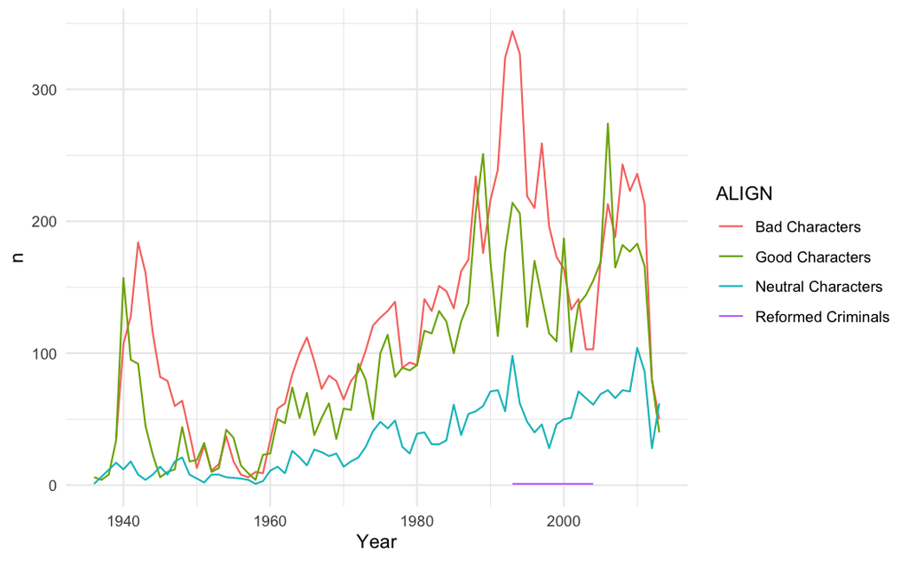

# lets look at efficiency

This graph is the clearest evidence yet of “bad characters’” poor staying power relative to “good” and “neutal” characters. “Bad character” appeaarances per character has only eclipsed 50 once in history, where “good” and “neutral” characters tend to fare far better.

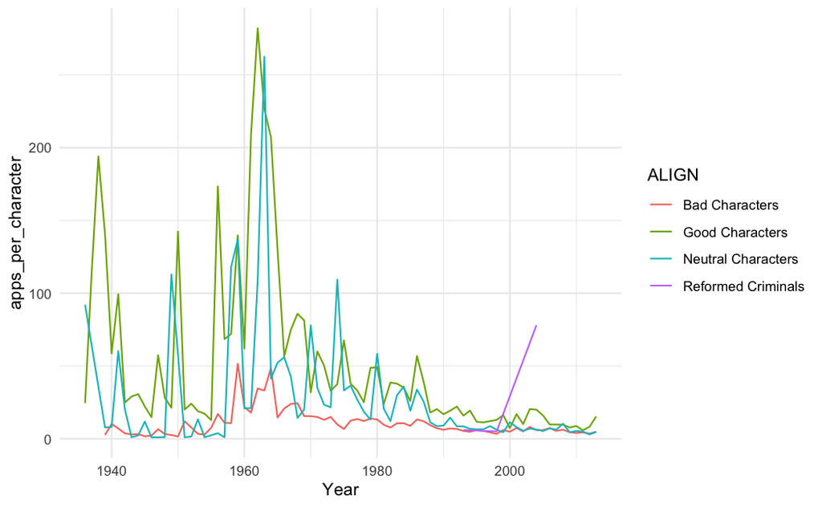

```r
jobs_test %>%
  mutate(job_yes = case_when(!is.na(job) ~ "has job",
                             is.na(job) ~ "no job",
                             TRUE ~ "huh")) %>%
  group_by(job_yes) %>%
  count(sort = T)

jobs_test$full_url <- dc_test$full_url

missing_jobs <- jobs_test %>%
  filter(is.na(job))

page2 <- missing_jobs$full_url

page2

gdxg2 <- lapply(page2, function(i) {

 tryCatch(
  i %>%
    read_html %>%
    html_nodes(".pi-group .pi-border-color:nth-child(7) .pi-font") %>%
    html_text(),
  error = function(e){NA}
 )
})

gdxg2

gdxg2[lengths(gdxg) == 0] <- NA_character_

hero_jobs_test2 <- unlist(gdxg2)

hero_jobs_test

dc_data$job <- hero_jobs_test2

hero_jobs_test2
```

# The Hero Economy

What are the most common jobs among comic book characters?

Going to start with a simple count.

```r
most_common_jobs_heroes <- comic_jobs %>%
  filter(!is.na(job),
         ALIGN == "Good Characters") %>%
  group_by(job) %>%
  count(sort = T) %>%
  head(20)

most_common_jobs_heroes

most_common_jobs_villains <- comic_jobs %>%
  filter(!is.na(job),
         ALIGN == "Bad Characters") %>%
  group_by(job) %>%
  count(sort = T) %>%
  head(20)

most_common_jobs_villains
```

```r
comic_jobs <- full_join(jobs_test_dc, jobs_test_marvel)


comic_jobs %>%
  filter(!is.na(job)) %>%
  mutate(job = str_replace_all(job, "; | · |;|·",",")) %>%
  group_by(job) %>%
  count(sort = T)
```

# Figuring a Way Around This

Okay so I think the best way to do this is to make a giant character vector with all the jobs, standardize the punctuation within the columns (I want all jobs to be separated by a comma), splitting on a comma, and turning the resulting vector into a dataframe that I can then count.

## In practice…not so simple

Okay So the first problem I’m having is removing trailing whitespace that is creating some duplicates. Tried several solutions to this but none of them seem to be working through mutating. I’ll try another approach below

```r
jobs <- table(unlist(strsplit(as.character(comic_jobs$job), ','))) %>%
  as.data.frame()

jobs %>%
  mutate(job = str_trim(Var1, side = c("both", "left", "right"))) %>%
  select(job, Freq) %>%
  arrange(desc(Freq))
```

## Another Approach

There’s probably a way around this using “str_replace_all” but I couldn’t find it so I decided that I will place jobs into broad categories based on “str_detect” rather than trying to standarize each individual “job” value.

This is in a way unfortunate because there’s no way I’ll be able to capture all of the different kinds of jobs in one industry (for example, how can I be sure I have captured all the different types of law enforcement), but it’s better for my sanity

# “Good” Jobs and “Bad” jobs

What are the most common jobs among “good characters” and “bad characters”

Jobs often act as a way to signal a character’s morality. There are certain jobs in our society that are more associated with ‘good’ or ‘bad’ behavior and writers take advantage of this for exposition.

Case in point – Police officer characters vs criminal characters:

```r
#Police
comic_jobs %>%
  group_by(ALIGN) %>%
  filter(str_detect(job,"POLICE OFFICER"))%>%
  count(ALIGN, sort = T)

#Criminals
comic_jobs %>%
  group_by(ALIGN) %>%
  filter(str_detect(job, "CRIMINAL")) %>%
  count(ALIGN, sort = T)
```

# Job titles often still carry the same political connotations and baggage as they do in real life

Case in point “Freedom Fights” vs. “Terrorists”

```r
comic_jobs %>%
  filter(str_detect(job, "FREEDOM FIGHTER")) %>%
  group_by(ALIGN) %>%
  count()

comic_jobs %>%
  filter(str_detect(job, "TERRORIST")) %>%
  group_by(ALIGN) %>%
  count()
```

## Journalists

```r
comic_jobs %>%
  filter(str_detect(job, "REPORTER|JOURNALIST|ANCHOR")) %>%
  group_by(ALIGN) %>%
  count(sort = T)

comic_jobs %>%
  filter(str_detect(job, "REPORTER|JOURNALIST|ANCHOR")) %>%
  arrange(desc(APPEARANCES))
```

# A more detailed look

Here I’d like to do some analysis of job categories more broadly, how those job categories break down ‘good character’ vs. ‘bad character’ and also Marvel vs. DC

### Law Enforcement

We took a brief look at this above, but it’s worth a deeper dive.

Law enforcement’s role in comics is often partnering with the hero, representing a moral base and the rule of law. They are important because they often legitimize comic book heroes’ vigilante violence by following it up with legitimate legal action.

For this category, I’ll include all police officers, detectivs, government agents, and soldiers,

```r
comic_jobs %>%
  filter(str_detect(job, "POLICE OFFICER|DETECTIVE|GOVERNMENT AGENT|SOLDIER")) %>%
  group_by(ALIGN) %>%
  count(sort = T) %>%
  filter(!is.na(ALIGN)) %>%
  filter(!str_detect(ALIGN, "Reformed")) %>%
  ggplot() +
  geom_col(aes(x = reorder(ALIGN, desc(n)), y = n, fill = ALIGN)) +
  scale_fill_brewer(palette = "Set1") +
  theme_minimal()
```

[output not shown]

```r
comic_jobs %>%
  filter(str_detect(job, "POLICE OFFICER|DETECTIVE|GOVERNMENT AGENT|SOLDIER")) %>%
  group_by(ALIGN, universe) %>%
  count(sort = T) %>%
  filter(!is.na(ALIGN)) %>%
  filter(!str_detect(ALIGN, "Reformed")) %>%
  ggplot(aes(fill=ALIGN, y=n, x=reorder(universe, -n))) +
  geom_bar(position="stack", stat="identity") +
  scale_fill_brewer(palette = "Set1") +
  theme_minimal()
```

[output not shown]

# Bussiness and Executives

Interesting to me that businessmen and executives are mostly good.

Some fun

```r
comic_jobs %>%
  filter(str_detect(job, "BUSINESSMAN|CEO|EXECUTIVE|MILLIONAIRE|BILLIONAIRE")) %>%
  group_by(job) %>%
  count(sort = T)
  filter(!is.na(ALIGN)) %>%
  filter(!str_detect(ALIGN, "Reformed"))



comic_jobs %>%
  filter(str_detect(job, "BUSINESSMAN|CEO|EXECUTIVE|MILLIONAIRE|BILLIONAIRE")) %>%
  group_by(ALIGN) %>%
  count(sort = T) %>%
  filter(!is.na(ALIGN)) %>%
  filter(!str_detect(ALIGN, "Reformed")) %>%
  ggplot() +
  geom_col(aes(x = reorder(ALIGN, desc(n)), y = n, fill = ALIGN)) +
  scale_fill_brewer(palette = "Set1") +
  theme_minimal()
```

A larger percentage of Business oriented DC characters are ‘Bad’ compared to their Marvel counterparts. This suggests DC has generally has a more negative view of business and what it represents than Marvel.

[figure not shown]

# Scientists and Engineers

Science and scientists play an interesting role in comics. On one hand, comic books seem to understand generally the importance of science. On the other, they view it also as mysterious and dangerous. The mad scientist trope distills this dichotomy into a character type.

```r
comic_jobs %>%
  filter(str_detect(job, "SCIENTIST|CHEMIST|BIOLOGIST|ZOOLOGIST|ENGINEER")) %>%
  group_by(ALIGN) %>%
  count(sort = T) %>%
  filter(!is.na(ALIGN)) %>%
  filter(!str_detect(ALIGN, "Reformed")) %>%
  ggplot() +
  geom_col(aes(x = reorder(ALIGN, desc(n)), y = n, fill = ALIGN)) +
  scale_fill_brewer(palette = "Set1") +
  theme_minimal()
```

[figure not shown]

# Conclusions

To the extent that there is a takeaway I think it is this: comic books are a reflection of our society. One of the most interesting takeaways from this project for me is that comic book companies seem to have given up on creating new, prolific characters. The lack of new IP and the heavy reliance on older properties is in line with what is going on with media at large.